# 425Project

Yusuf Sina Öztürk - Recep Talha Bölükbaş

Last edited Temmuz 01, 2021

### Introduction

[output not shown]

### Analyze Variables and Manipulations

We do not need second index in data.

```r
datatrain <- datatrain[,-c("X")]
```

`team_id` and `team_name` are always the same in entire data set.

```r
datatrain <- datatrain[,-c("team_id", "team_name")]
datatrain <- datatrain[,-c("game_date")]
```

#### Checking lon and lat attributes

First we think `lon` and `lat` attributes represents latitude and longitude. If it is, then they should be correlated with `loc_x` and `loc_y`. Therefore, we checked correlations between `lon` with `loc_x` and `lat` with `loc_y`.

```r
cor_lon_x <- cor.test(datatrain$lon, datatrain$loc_x, method=c("pearson", "kendall", "spearman"))
cor_lon_x$estimate
```

```
## cor
##   1
```

Now, we sure that `lon` and `loc_x`, because these two have pure correlation. We can delete `lon` attribute from data set.

```r
datatrain <- datatrain[,-c("lon")]
```

We also need to check `lat` and `loc_y` correlation.

```r
cor_lat_y <- cor.test(datatrain$lat, datatrain$loc_y, method=c("pearson", "kendall", "spearman"))
cor_lat_y$estimate
```

```
## cor
##  -1
```

Correlation test also shows us that `lat` and `loc_y` has pure negative correlation. Therefore, we can get rid of `lat` attribute.

```r
datatrain <- datatrain[,-c("lat")]
```

#### Adding home_play

Another attribute ``matchup` shows us that whether match played at home or away with using vs. and @ symbols. With using these symbols, we generate `home_play` attribute which is `TRUE` if match played at home, vice versa.

```r
contains_vs <- c()
for (i in 1:nrow(datatrain)) {
  contains_vs[i] <- str_contains(datatrain$matchup[i], "vs")
}

datatrain <- datatrain[, home_play:=contains_vs] # if home_play is TRUE then match played at home, vice versa
```

Now, we do not need `matchup` attribute anymore, because we already have `opponent` and `home_play` attributes.

```r
datatrain <- datatrain[,-c("matchup")]
```

#### Adding time_remaining

Here, we have `seconds_remaining` and `minutes_remaining` which represents time to the end of the period. However, we need think these two attributes together. Therefore, I multiply minutes with 60 and add seconds at `time_remaining` attribute.

```r
datatrain <- datatrain[, time_remaining:=minutes_remaining*60 + datatrain$seconds_remaining]
```

So we do not need `seconds_remaining` and `minutes_remaining` anymore.

```r
datatrain <- datatrain[,-c("minutes_remaining", "seconds_remaining")]
```

Here, there is no more useless attribute by only looking at the data set. Therefore, we stopped here doing manipulation.

```r
datatest <- datatest[,-c("X", "X.1")] # we have one more useless index attribute in this set
datatest <- datatest[,-c("lat","lon")]
datatest <- datatest[,-c("team_id", "team_name")]
datatest <- datatest[,-c("game_date")]
contains_vs_test <- c()
for (i in 1:nrow(datatest)) {
  contains_vs_test[i] <- str_contains(datatest$matchup[i], "vs")
}
datatest <- datatest[, home_play:=contains_vs_test]
datatest <- datatest[, -c("matchup")]
datatest <- datatest[, time_remaining:=minutes_remaining*60 + datatest$seconds_remaining]
datatest <- datatest[,-c("minutes_remaining", "seconds_remaining")]
```

### Divide Data Into Test and Train Sets

Here we used split ratio as 0.9 because the actual data also splitted by using the same ratio.

```r
set.seed(0) # to get the same split for each time
split = sample.split(datatrain$shot_made_flag, SplitRatio = 0.9)
kobetrain = subset(datatrain, split == TRUE)
kobetest = subset(datatrain, split == FALSE)
```

Now, we can built our models using `kobetrain` and test our models using `kobetest`.

### Logistic Regression Models

First, we need to detect which attributes have the effect on the models. Therefore, we start with logistic regression models.

With adding all attributes into model to check the signifances of the attributes.

```r
lr1 <- glm(shot_made_flag~.,data = kobetrain, family = binomial )
summary(lr1)
```

```
##
## Call:
## glm(formula = shot_made_flag ~ ., family = binomial, data = kobetrain)
##
## Deviance Residuals:
##     Min       1Q   Median       3Q      Max
## -3.1066  -0.9324  -0.7796   1.0844   2.8019
##
## Coefficients: (7 not defined because of singularities)
##                                              Estimate Std. Error z value
## (Intercept)                                 1.030e+03  1.483e+03   0.694
## action_typeAlley Oop Layup shot            -2.640e+00  7.816e-01  -3.377
## action_typeCutting Layup Shot              -2.227e+00  1.138e+00  -1.956
## action_typeDriving Bank shot               -3.504e+00  1.591e+00  -2.202
## action_typeDriving Dunk Shot               -9.765e-02  8.278e-01  -0.118
## action_typeDriving Finger Roll Layup Shot  -1.427e+00  8.593e-01  -1.660
## action_typeDriving Finger Roll Shot        -2.017e+00  8.052e-01  -2.505
## action_typeDriving Floating Bank Jump Shot  1.072e+01  5.354e+02   0.020
## action_typeDriving Floating Jump Shot      -3.659e+00  1.435e+00  -2.550
## action_typeDriving Hook Shot               -3.165e+00  9.694e-01  -3.265
## action_typeDriving Jump shot               -3.563e+00  8.921e-01  -3.994
## action_typeDriving Layup Shot              -2.558e+00  7.194e-01  -3.556
## action_typeDriving Reverse Layup Shot      -2.572e+00  7.675e-01  -3.351
## action_typeDriving Slam Dunk Shot           9.083e-02  1.244e+00   0.073
## action_typeDunk Shot                       -2.318e+00  7.397e-01  -3.134
## action_typeFadeaway Bank shot              -1.483e+00  9.578e-01  -1.548
## action_typeFadeaway Jump Shot              -3.251e+00  7.348e-01  -4.425
## action_typeFinger Roll Layup Shot          -1.397e+00  1.038e+00  -1.346
## action_typeFinger Roll Shot                -3.606e+00  8.363e-01  -4.312
## action_typeFloating Jump shot              -2.569e+00  7.713e-01  -3.331
## action_typeFollow Up Dunk Shot             -1.403e+00  1.276e+00  -1.100
## action_typeHook Bank Shot                   1.012e+01  2.392e+02   0.042
## action_typeHook Shot                       -4.181e+00  7.709e-01  -5.424
## action_typeJump Bank Shot                  -2.209e+00  7.466e-01  -2.959
## action_typeJump Hook Shot                  -2.442e+00  8.979e-01  -2.720
## action_typeJump Shot                       -4.411e+00  7.305e-01  -6.038
## action_typeLayup Shot                      -4.126e+00  7.183e-01  -5.745
## action_typePullup Bank shot                -2.947e+00  9.787e-01  -3.011
## action_typePullup Jump shot                -2.541e+00  7.419e-01  -3.425
## action_typePutback Dunk Shot                9.863e+00  5.354e+02   0.018
```

[output cut: 238 more lines]

```
## opponentUTA                                0.988072
## opponentVAN                                0.417729
## opponentWAS                                0.985805
## home_playTRUE                              0.173218
## time_remaining                             0.019669 *
## ---
## Signif. codes:  0 '***' 0.001 '**' 0.01 '*' 0.05 '.' 0.1 ' ' 1
##
## (Dispersion parameter for binomial family taken to be 1)
##
##     Null deviance: 28612  on 20813  degrees of freedom
## Residual deviance: 25116  on 20685  degrees of freedom
## AIC: 25374
##
## Number of Fisher Scoring iterations: 12
```

From the beginning of the project, we have the insight that `distance` attribute should have some significance in the model. After looking summary of `lr1`, we see that `shot_zone_range` has nothing but the categorical attribute for distance. Therefore, we start with eliminate this attribute first.

```r
lr2 <- glm(shot_made_flag~. - shot_zone_range,data = kobetrain, family = binomial )
summary(lr2)
```

```
##
## Call:
## glm(formula = shot_made_flag ~ . - shot_zone_range, family = binomial,
##     data = kobetrain)
##
## Deviance Residuals:
##     Min       1Q   Median       3Q      Max
## -3.1071  -0.9290  -0.7857   1.0813   2.9266
##
## Coefficients: (5 not defined because of singularities)
##                                              Estimate Std. Error z value
## (Intercept)                                 1.025e+03  1.483e+03   0.692
## action_typeAlley Oop Layup shot            -2.641e+00  7.816e-01  -3.379
## action_typeCutting Layup Shot              -2.250e+00  1.138e+00  -1.977
## action_typeDriving Bank shot               -3.626e+00  1.589e+00  -2.281
## action_typeDriving Dunk Shot               -9.637e-02  8.278e-01  -0.116
## action_typeDriving Finger Roll Layup Shot  -1.438e+00  8.592e-01  -1.673
## action_typeDriving Finger Roll Shot        -2.033e+00  8.051e-01  -2.525
## action_typeDriving Floating Bank Jump Shot  1.059e+01  5.354e+02   0.020
## action_typeDriving Floating Jump Shot      -3.734e+00  1.432e+00  -2.608
## action_typeDriving Hook Shot               -3.281e+00  9.685e-01  -3.388
## action_typeDriving Jump shot               -3.646e+00  8.915e-01  -4.090
## action_typeDriving Layup Shot              -2.561e+00  7.194e-01  -3.559
## action_typeDriving Reverse Layup Shot      -2.587e+00  7.675e-01  -3.370
## action_typeDriving Slam Dunk Shot           8.709e-02  1.243e+00   0.070
## action_typeDunk Shot                       -2.314e+00  7.397e-01  -3.129
## action_typeFadeaway Bank shot              -1.525e+00  9.578e-01  -1.592
## action_typeFadeaway Jump Shot              -3.254e+00  7.346e-01  -4.430
## action_typeFinger Roll Layup Shot          -1.445e+00  1.038e+00  -1.393
## action_typeFinger Roll Shot                -3.650e+00  8.361e-01  -4.365
## action_typeFloating Jump shot              -2.650e+00  7.709e-01  -3.438
## action_typeFollow Up Dunk Shot             -1.398e+00  1.276e+00  -1.096
## action_typeHook Bank Shot                   1.003e+01  2.393e+02   0.042
## action_typeHook Shot                       -4.265e+00  7.708e-01  -5.533
## action_typeJump Bank Shot                  -2.248e+00  7.464e-01  -3.012
## action_typeJump Hook Shot                  -2.549e+00  8.978e-01  -2.839
## action_typeJump Shot                       -4.425e+00  7.304e-01  -6.058
## action_typeLayup Shot                      -4.129e+00  7.183e-01  -5.748
## action_typePullup Bank shot                -3.000e+00  9.784e-01  -3.067
## action_typePullup Jump shot                -2.538e+00  7.418e-01  -3.421
```

[output cut: 231 more lines]

```
## opponentUTA                                0.941556
## opponentVAN                                0.400947
## opponentWAS                                0.918689
## home_playTRUE                              0.165986
## time_remaining                             0.017108 *
## ---
## Signif. codes:  0 '***' 0.001 '**' 0.01 '*' 0.05 '.' 0.1 ' ' 1
##
## (Dispersion parameter for binomial family taken to be 1)
##
##     Null deviance: 28612  on 20813  degrees of freedom
## Residual deviance: 25137  on 20687  degrees of freedom
## AIC: 25391
##
## Number of Fisher Scoring iterations: 12
```

Also, similar with `shot_zone_range`, `shot_zone_area` is categorical attribute for `loc_x` and `loc_y`. Because it is simply divide the play ground into zones. Therefore, we subtract `shot_zone_area`.

```r
lr3 <- glm(shot_made_flag~. - shot_zone_range - shot_zone_area,data = kobetrain, family = binomial )
summary(lr3)
```

```
##
## Call:
## glm(formula = shot_made_flag ~ . - shot_zone_range - shot_zone_area,
##     family = binomial, data = kobetrain)
##
## Deviance Residuals:
##     Min       1Q   Median       3Q      Max
## -3.1078  -0.9288  -0.7906   1.0773   2.9438
##
## Coefficients: (5 not defined because of singularities)
##                                              Estimate Std. Error z value
## (Intercept)                                 1.119e+03  1.472e+03   0.760
## action_typeAlley Oop Layup shot            -2.642e+00  7.816e-01  -3.380
## action_typeCutting Layup Shot              -2.261e+00  1.137e+00  -1.988
## action_typeDriving Bank shot               -3.573e+00  1.590e+00  -2.247
## action_typeDriving Dunk Shot               -9.571e-02  8.278e-01  -0.116
## action_typeDriving Finger Roll Layup Shot  -1.439e+00  8.592e-01  -1.675
## action_typeDriving Finger Roll Shot        -2.029e+00  8.051e-01  -2.520
## action_typeDriving Floating Bank Jump Shot  1.044e+01  5.354e+02   0.020
## action_typeDriving Floating Jump Shot      -3.769e+00  1.433e+00  -2.630
## action_typeDriving Hook Shot               -3.272e+00  9.684e-01  -3.378
## action_typeDriving Jump shot               -3.648e+00  8.916e-01  -4.091
## action_typeDriving Layup Shot              -2.559e+00  7.194e-01  -3.557
## action_typeDriving Reverse Layup Shot      -2.584e+00  7.675e-01  -3.366
## action_typeDriving Slam Dunk Shot           8.250e-02  1.243e+00   0.066
## action_typeDunk Shot                       -2.314e+00  7.397e-01  -3.129
## action_typeFadeaway Bank shot              -1.576e+00  9.576e-01  -1.645
## action_typeFadeaway Jump Shot              -3.285e+00  7.344e-01  -4.474
## action_typeFinger Roll Layup Shot          -1.448e+00  1.038e+00  -1.396
## action_typeFinger Roll Shot                -3.644e+00  8.362e-01  -4.358
## action_typeFloating Jump shot              -2.653e+00  7.709e-01  -3.442
## action_typeFollow Up Dunk Shot             -1.397e+00  1.276e+00  -1.095
## action_typeHook Bank Shot                   1.006e+01  2.393e+02   0.042
## action_typeHook Shot                       -4.266e+00  7.707e-01  -5.535
## action_typeJump Bank Shot                  -2.301e+00  7.461e-01  -3.084
## action_typeJump Hook Shot                  -2.542e+00  8.977e-01  -2.832
## action_typeJump Shot                       -4.435e+00  7.303e-01  -6.072
## action_typeLayup Shot                      -4.129e+00  7.183e-01  -5.748
## action_typePullup Bank shot                -3.056e+00  9.779e-01  -3.125
## action_typePullup Jump shot                -2.552e+00  7.417e-01  -3.440
```

[output cut: 221 more lines]

```
## opponentUTA                                0.929642
## opponentVAN                                0.398057
## opponentWAS                                0.939438
## home_playTRUE                              0.172112
## time_remaining                             0.014767 *
## ---
## Signif. codes:  0 '***' 0.001 '**' 0.01 '*' 0.05 '.' 0.1 ' ' 1
##
## (Dispersion parameter for binomial family taken to be 1)
##
##     Null deviance: 28612  on 20813  degrees of freedom
## Residual deviance: 25162  on 20692  degrees of freedom
## AIC: 25406
##
## Number of Fisher Scoring iterations: 12
```

We think that `game_event_id` and `game_id` cannot affect the model but we want to see it in the model. As we can see from the model summaries, these two attributes has no affect on the model.

```r
lr4 <- glm(shot_made_flag~. - shot_zone_range - shot_zone_area - game_id - game_event_id,data = kobetrain, family = binomial )
summary(lr4)
```

```
##
## Call:
## glm(formula = shot_made_flag ~ . - shot_zone_range - shot_zone_area -
##     game_id - game_event_id, family = binomial, data = kobetrain)
##
## Deviance Residuals:
##     Min       1Q   Median       3Q      Max
## -3.1021  -0.9286  -0.7908   1.0789   2.9410
##
## Coefficients: (5 not defined because of singularities)
##                                              Estimate Std. Error z value
## (Intercept)                                 2.829e+00  8.407e-01   3.364
## action_typeAlley Oop Layup shot            -2.640e+00  7.816e-01  -3.378
## action_typeCutting Layup Shot              -2.262e+00  1.138e+00  -1.988
## action_typeDriving Bank shot               -3.580e+00  1.590e+00  -2.251
## action_typeDriving Dunk Shot               -9.519e-02  8.278e-01  -0.115
## action_typeDriving Finger Roll Layup Shot  -1.440e+00  8.592e-01  -1.677
## action_typeDriving Finger Roll Shot        -2.030e+00  8.051e-01  -2.521
## action_typeDriving Floating Bank Jump Shot  1.878e+01  3.455e+04   0.001
## action_typeDriving Floating Jump Shot      -3.759e+00  1.433e+00  -2.624
## action_typeDriving Hook Shot               -3.275e+00  9.684e-01  -3.382
## action_typeDriving Jump shot               -3.643e+00  8.916e-01  -4.085
## action_typeDriving Layup Shot              -2.559e+00  7.194e-01  -3.557
## action_typeDriving Reverse Layup Shot      -2.584e+00  7.675e-01  -3.367
## action_typeDriving Slam Dunk Shot           8.169e-02  1.243e+00   0.066
## action_typeDunk Shot                       -2.314e+00  7.397e-01  -3.128
## action_typeFadeaway Bank shot              -1.571e+00  9.575e-01  -1.640
## action_typeFadeaway Jump Shot              -3.286e+00  7.344e-01  -4.474
## action_typeFinger Roll Layup Shot          -1.446e+00  1.038e+00  -1.393
## action_typeFinger Roll Shot                -3.641e+00  8.362e-01  -4.355
## action_typeFloating Jump shot              -2.651e+00  7.709e-01  -3.439
## action_typeFollow Up Dunk Shot             -1.395e+00  1.276e+00  -1.093
## action_typeHook Bank Shot                   1.269e+01  8.882e+02   0.014
## action_typeHook Shot                       -4.264e+00  7.707e-01  -5.533
## action_typeJump Bank Shot                  -2.299e+00  7.461e-01  -3.082
## action_typeJump Hook Shot                  -2.543e+00  8.976e-01  -2.833
## action_typeJump Shot                       -4.433e+00  7.303e-01  -6.070
## action_typeLayup Shot                      -4.128e+00  7.183e-01  -5.747
## action_typePullup Bank shot                -3.054e+00  9.779e-01  -3.124
## action_typePullup Jump shot                -2.554e+00  7.416e-01  -3.443
```

[output cut: 217 more lines]

```
## opponentUTA                                0.914173
## opponentVAN                                0.400082
## opponentWAS                                0.936636
## home_playTRUE                              0.159126
## time_remaining                             3.91e-05 ***
## ---
## Signif. codes:  0 '***' 0.001 '**' 0.01 '*' 0.05 '.' 0.1 ' ' 1
##
## (Dispersion parameter for binomial family taken to be 1)
##
##     Null deviance: 28612  on 20813  degrees of freedom
## Residual deviance: 25163  on 20694  degrees of freedom
## AIC: 25403
##
## Number of Fisher Scoring iterations: 15
```

`opponent` attribute is a huge categorical attribute and almost all of them has any significance in the model. Therefore, we think that this attribute will going to affect model negatively.

```r
lr5 <- glm(shot_made_flag~. - shot_zone_range - shot_zone_area- game_id - game_event_id - opponent,data = kobetrain, family = binomial )
summary(lr5)
```

```
##
## Call:
## glm(formula = shot_made_flag ~ . - shot_zone_range - shot_zone_area -
##     game_id - game_event_id - opponent, family = binomial, data = kobetrain)
##
## Deviance Residuals:
##     Min       1Q   Median       3Q      Max
## -3.0819  -0.9285  -0.7999   1.0737   2.9435
##
## Coefficients: (5 not defined because of singularities)
##                                              Estimate Std. Error z value
## (Intercept)                                 2.860e+00  8.323e-01   3.436
## action_typeAlley Oop Layup shot            -2.644e+00  7.813e-01  -3.384
## action_typeCutting Layup Shot              -2.417e+00  1.128e+00  -2.143
## action_typeDriving Bank shot               -3.544e+00  1.590e+00  -2.228
## action_typeDriving Dunk Shot               -1.173e-01  8.276e-01  -0.142
## action_typeDriving Finger Roll Layup Shot  -1.472e+00  8.588e-01  -1.714
## action_typeDriving Finger Roll Shot        -2.051e+00  8.048e-01  -2.548
## action_typeDriving Floating Bank Jump Shot  1.046e+01  5.354e+02   0.020
## action_typeDriving Floating Jump Shot      -3.752e+00  1.431e+00  -2.622
## action_typeDriving Hook Shot               -3.376e+00  9.648e-01  -3.499
## action_typeDriving Jump shot               -3.649e+00  8.908e-01  -4.097
## action_typeDriving Layup Shot              -2.574e+00  7.193e-01  -3.578
## action_typeDriving Reverse Layup Shot      -2.641e+00  7.670e-01  -3.443
## action_typeDriving Slam Dunk Shot           7.026e-03  1.242e+00   0.006
## action_typeDunk Shot                       -2.316e+00  7.395e-01  -3.132
## action_typeFadeaway Bank shot              -1.576e+00  9.570e-01  -1.647
## action_typeFadeaway Jump Shot              -3.309e+00  7.342e-01  -4.507
## action_typeFinger Roll Layup Shot          -1.476e+00  1.037e+00  -1.423
## action_typeFinger Roll Shot                -3.653e+00  8.357e-01  -4.372
## action_typeFloating Jump shot              -2.687e+00  7.704e-01  -3.488
## action_typeFollow Up Dunk Shot             -1.443e+00  1.275e+00  -1.132
## action_typeHook Bank Shot                   1.005e+01  2.391e+02   0.042
## action_typeHook Shot                       -4.258e+00  7.702e-01  -5.528
## action_typeJump Bank Shot                  -2.302e+00  7.459e-01  -3.086
## action_typeJump Hook Shot                  -2.564e+00  8.972e-01  -2.858
## action_typeJump Shot                       -4.430e+00  7.301e-01  -6.069
## action_typeLayup Shot                      -4.126e+00  7.181e-01  -5.745
## action_typePullup Bank shot                -3.050e+00  9.768e-01  -3.122
## action_typePullup Jump shot                -2.588e+00  7.413e-01  -3.490
```

[output cut: 153 more lines]

```
## shot_zone_basicMid-Range                   0.086256 .
## shot_zone_basicRestricted Area             0.041006 *
## shot_zone_basicRight Corner 3              0.059397 .
## home_playTRUE                              0.176111
## time_remaining                             4.01e-05 ***
## ---
## Signif. codes:  0 '***' 0.001 '**' 0.01 '*' 0.05 '.' 0.1 ' ' 1
##
## (Dispersion parameter for binomial family taken to be 1)
##
##     Null deviance: 28612  on 20813  degrees of freedom
## Residual deviance: 25205  on 20726  degrees of freedom
## AIC: 25381
##
## Number of Fisher Scoring iterations: 12
```

While we start to the project `playoff` attribute should have some affect on the model. Because by our personel knowledge about NBA, in playoffs players play better than normal league. However, it does not affect model too much.

```r
lr6 <- glm(shot_made_flag~. - shot_zone_range - shot_zone_area- game_id - game_event_id - opponent - playoffs,data = kobetrain, family = binomial )
summary(lr6)
```

```
##
## Call:
## glm(formula = shot_made_flag ~ . - shot_zone_range - shot_zone_area -
##     game_id - game_event_id - opponent - playoffs, family = binomial,
##     data = kobetrain)
##
## Deviance Residuals:
##     Min       1Q   Median       3Q      Max
## -3.0800  -0.9281  -0.8006   1.0733   2.9471
##
## Coefficients: (5 not defined because of singularities)
##                                              Estimate Std. Error z value
## (Intercept)                                 2.857e+00  8.323e-01   3.433
## action_typeAlley Oop Layup shot            -2.642e+00  7.813e-01  -3.382
## action_typeCutting Layup Shot              -2.418e+00  1.128e+00  -2.144
## action_typeDriving Bank shot               -3.539e+00  1.591e+00  -2.225
## action_typeDriving Dunk Shot               -1.178e-01  8.276e-01  -0.142
## action_typeDriving Finger Roll Layup Shot  -1.474e+00  8.588e-01  -1.716
## action_typeDriving Finger Roll Shot        -2.053e+00  8.048e-01  -2.551
## action_typeDriving Floating Bank Jump Shot  1.046e+01  5.354e+02   0.020
## action_typeDriving Floating Jump Shot      -3.752e+00  1.431e+00  -2.622
## action_typeDriving Hook Shot               -3.375e+00  9.647e-01  -3.498
## action_typeDriving Jump shot               -3.652e+00  8.908e-01  -4.100
## action_typeDriving Layup Shot              -2.575e+00  7.193e-01  -3.580
## action_typeDriving Reverse Layup Shot      -2.640e+00  7.670e-01  -3.442
## action_typeDriving Slam Dunk Shot           6.188e-03  1.242e+00   0.005
## action_typeDunk Shot                       -2.316e+00  7.395e-01  -3.132
## action_typeFadeaway Bank shot              -1.578e+00  9.570e-01  -1.649
## action_typeFadeaway Jump Shot              -3.310e+00  7.342e-01  -4.508
## action_typeFinger Roll Layup Shot          -1.479e+00  1.037e+00  -1.427
## action_typeFinger Roll Shot                -3.654e+00  8.357e-01  -4.373
## action_typeFloating Jump shot              -2.688e+00  7.704e-01  -3.489
## action_typeFollow Up Dunk Shot             -1.439e+00  1.275e+00  -1.128
## action_typeHook Bank Shot                   1.005e+01  2.391e+02   0.042
## action_typeHook Shot                       -4.256e+00  7.702e-01  -5.525
## action_typeJump Bank Shot                  -2.303e+00  7.459e-01  -3.088
## action_typeJump Hook Shot                  -2.563e+00  8.972e-01  -2.857
## action_typeJump Shot                       -4.431e+00  7.301e-01  -6.069
## action_typeLayup Shot                      -4.127e+00  7.181e-01  -5.746
## action_typePullup Bank shot                -3.049e+00  9.769e-01  -3.121
```

[output cut: 152 more lines]

```
## shot_zone_basicMid-Range                   0.086155 .
## shot_zone_basicRestricted Area             0.040732 *
## shot_zone_basicRight Corner 3              0.059089 .
## home_playTRUE                              0.172824
## time_remaining                             4.19e-05 ***
## ---
## Signif. codes:  0 '***' 0.001 '**' 0.01 '*' 0.05 '.' 0.1 ' ' 1
##
## (Dispersion parameter for binomial family taken to be 1)
##
##     Null deviance: 28612  on 20813  degrees of freedom
## Residual deviance: 25205  on 20727  degrees of freedom
## AIC: 25379
##
## Number of Fisher Scoring iterations: 12
```

Later we realize that `shot_type` has the correlation with distance. (3PT and 2PT).

```r
lr7 <- glm(shot_made_flag~. - shot_zone_range - shot_zone_area- game_id - game_event_id - opponent - playoffs - shot_type,data = kobetrain, family = binomial )
summary(lr7)
```

```
##
## Call:
## glm(formula = shot_made_flag ~ . - shot_zone_range - shot_zone_area -
##     game_id - game_event_id - opponent - playoffs - shot_type,
##     family = binomial, data = kobetrain)
##
## Deviance Residuals:
##     Min       1Q   Median       3Q      Max
## -3.0798  -0.9283  -0.8007   1.0736   2.9521
##
## Coefficients: (5 not defined because of singularities)
##                                              Estimate Std. Error z value
## (Intercept)                                 3.216e+00  7.549e-01   4.260
## action_typeAlley Oop Layup shot            -2.642e+00  7.813e-01  -3.382
## action_typeCutting Layup Shot              -2.419e+00  1.128e+00  -2.145
## action_typeDriving Bank shot               -3.540e+00  1.591e+00  -2.226
## action_typeDriving Dunk Shot               -1.182e-01  8.276e-01  -0.143
## action_typeDriving Finger Roll Layup Shot  -1.474e+00  8.588e-01  -1.717
## action_typeDriving Finger Roll Shot        -2.053e+00  8.048e-01  -2.551
## action_typeDriving Floating Bank Jump Shot  1.045e+01  5.354e+02   0.020
## action_typeDriving Floating Jump Shot      -3.753e+00  1.431e+00  -2.622
## action_typeDriving Hook Shot               -3.375e+00  9.648e-01  -3.498
## action_typeDriving Jump shot               -3.631e+00  8.900e-01  -4.080
## action_typeDriving Layup Shot              -2.576e+00  7.193e-01  -3.582
## action_typeDriving Reverse Layup Shot      -2.640e+00  7.670e-01  -3.443
## action_typeDriving Slam Dunk Shot           6.147e-03  1.242e+00   0.005
## action_typeDunk Shot                       -2.318e+00  7.395e-01  -3.135
## action_typeFadeaway Bank shot              -1.578e+00  9.570e-01  -1.648
## action_typeFadeaway Jump Shot              -3.312e+00  7.342e-01  -4.511
## action_typeFinger Roll Layup Shot          -1.479e+00  1.037e+00  -1.427
## action_typeFinger Roll Shot                -3.654e+00  8.357e-01  -4.372
## action_typeFloating Jump shot              -2.688e+00  7.704e-01  -3.489
## action_typeFollow Up Dunk Shot             -1.439e+00  1.275e+00  -1.128
## action_typeHook Bank Shot                   1.005e+01  2.391e+02   0.042
## action_typeHook Shot                       -4.256e+00  7.702e-01  -5.525
## action_typeJump Bank Shot                  -2.303e+00  7.459e-01  -3.088
## action_typeJump Hook Shot                  -2.563e+00  8.972e-01  -2.856
## action_typeJump Shot                       -4.432e+00  7.301e-01  -6.071
## action_typeLayup Shot                      -4.129e+00  7.181e-01  -5.749
## action_typePullup Bank shot                -3.049e+00  9.769e-01  -3.121
```

[output cut: 150 more lines]

```
## shot_zone_basicMid-Range                   0.000806 ***
## shot_zone_basicRestricted Area             0.030430 *
## shot_zone_basicRight Corner 3              0.057720 .
## home_playTRUE                              0.179551
## time_remaining                             4.09e-05 ***
## ---
## Signif. codes:  0 '***' 0.001 '**' 0.01 '*' 0.05 '.' 0.1 ' ' 1
##
## (Dispersion parameter for binomial family taken to be 1)
##
##     Null deviance: 28612  on 20813  degrees of freedom
## Residual deviance: 25206  on 20728  degrees of freedom
## AIC: 25378
##
## Number of Fisher Scoring iterations: 12
```

We also relaize that `action_type` is a huge subset of `combined_shot_type`. Therefore, we do not need `combined_shot_type` attribute in the models.

```r
lr8 <- glm(shot_made_flag~. - shot_zone_range - shot_zone_area- game_id - game_event_id - opponent - playoffs - shot_type - combined_shot_type,data = kobetrain, family = binomial )
summary(lr8)
```

```
##
## Call:
## glm(formula = shot_made_flag ~ . - shot_zone_range - shot_zone_area -
##     game_id - game_event_id - opponent - playoffs - shot_type -
##     combined_shot_type, family = binomial, data = kobetrain)
##
## Deviance Residuals:
##     Min       1Q   Median       3Q      Max
## -3.0798  -0.9283  -0.8007   1.0736   2.9521
##
## Coefficients:
##                                              Estimate Std. Error z value
## (Intercept)                                 3.216e+00  7.549e-01   4.260
## action_typeAlley Oop Layup shot            -2.642e+00  7.813e-01  -3.382
## action_typeCutting Layup Shot              -2.419e+00  1.128e+00  -2.145
## action_typeDriving Bank shot               -3.540e+00  1.591e+00  -2.226
## action_typeDriving Dunk Shot               -1.182e-01  8.276e-01  -0.143
## action_typeDriving Finger Roll Layup Shot  -1.474e+00  8.588e-01  -1.717
## action_typeDriving Finger Roll Shot        -2.053e+00  8.048e-01  -2.551
## action_typeDriving Floating Bank Jump Shot  1.045e+01  5.354e+02   0.020
## action_typeDriving Floating Jump Shot      -3.753e+00  1.431e+00  -2.622
## action_typeDriving Hook Shot               -3.375e+00  9.648e-01  -3.498
## action_typeDriving Jump shot               -3.631e+00  8.900e-01  -4.080
## action_typeDriving Layup Shot              -2.576e+00  7.193e-01  -3.582
## action_typeDriving Reverse Layup Shot      -2.640e+00  7.670e-01  -3.443
## action_typeDriving Slam Dunk Shot           6.147e-03  1.242e+00   0.005
## action_typeDunk Shot                       -2.318e+00  7.395e-01  -3.135
## action_typeFadeaway Bank shot              -1.578e+00  9.570e-01  -1.648
## action_typeFadeaway Jump Shot              -3.312e+00  7.342e-01  -4.511
## action_typeFinger Roll Layup Shot          -1.479e+00  1.037e+00  -1.427
## action_typeFinger Roll Shot                -3.654e+00  8.357e-01  -4.372
## action_typeFloating Jump shot              -2.688e+00  7.704e-01  -3.489
## action_typeFollow Up Dunk Shot             -1.439e+00  1.275e+00  -1.128
## action_typeHook Bank Shot                   1.005e+01  2.391e+02   0.042
## action_typeHook Shot                       -4.256e+00  7.702e-01  -5.525
## action_typeJump Bank Shot                  -2.303e+00  7.459e-01  -3.088
## action_typeJump Hook Shot                  -2.563e+00  8.972e-01  -2.856
## action_typeJump Shot                       -4.432e+00  7.301e-01  -6.071
## action_typeLayup Shot                      -4.129e+00  7.181e-01  -5.749
## action_typePullup Bank shot                -3.049e+00  9.769e-01  -3.121
```

[output cut: 140 more lines]

```
## shot_zone_basicMid-Range                   0.000806 ***
## shot_zone_basicRestricted Area             0.030430 *
## shot_zone_basicRight Corner 3              0.057720 .
## home_playTRUE                              0.179551
## time_remaining                             4.09e-05 ***
## ---
## Signif. codes:  0 '***' 0.001 '**' 0.01 '*' 0.05 '.' 0.1 ' ' 1
##
## (Dispersion parameter for binomial family taken to be 1)
##
##     Null deviance: 28612  on 20813  degrees of freedom
## Residual deviance: 25206  on 20728  degrees of freedom
## AIC: 25378
##
## Number of Fisher Scoring iterations: 12
```

Here, there is a difficult decision. Some seasons have the affect on models but others have not. Now, we subtract `season` attribute but we are not sure.

```r
lr9 <- glm(shot_made_flag~. - shot_zone_range - shot_zone_area- game_id - game_event_id - opponent - playoffs - shot_type - combined_shot_type - season,data = kobetrain, family = binomial )
summary(lr9)
```

```
##
## Call:
## glm(formula = shot_made_flag ~ . - shot_zone_range - shot_zone_area -
##     game_id - game_event_id - opponent - playoffs - shot_type -
##     combined_shot_type - season, family = binomial, data = kobetrain)
##
## Deviance Residuals:
##     Min       1Q   Median       3Q      Max
## -3.0606  -0.9214  -0.8261   1.0675   2.9695
##
## Coefficients:
##                                              Estimate Std. Error z value
## (Intercept)                                 3.285e+00  7.437e-01   4.417
## action_typeAlley Oop Layup shot            -2.648e+00  7.811e-01  -3.391
## action_typeCutting Layup Shot              -2.979e+00  1.124e+00  -2.649
## action_typeDriving Bank shot               -3.596e+00  1.592e+00  -2.258
## action_typeDriving Dunk Shot               -1.535e-01  8.274e-01  -0.186
## action_typeDriving Finger Roll Layup Shot  -1.541e+00  8.581e-01  -1.796
## action_typeDriving Finger Roll Shot        -2.072e+00  8.044e-01  -2.576
## action_typeDriving Floating Bank Jump Shot  9.839e+00  5.354e+02   0.018
## action_typeDriving Floating Jump Shot      -4.354e+00  1.428e+00  -3.049
## action_typeDriving Hook Shot               -3.653e+00  9.613e-01  -3.800
## action_typeDriving Jump shot               -3.782e+00  8.887e-01  -4.255
## action_typeDriving Layup Shot              -2.620e+00  7.190e-01  -3.643
## action_typeDriving Reverse Layup Shot      -2.776e+00  7.661e-01  -3.624
## action_typeDriving Slam Dunk Shot          -5.076e-02  1.241e+00  -0.041
## action_typeDunk Shot                       -2.348e+00  7.392e-01  -3.176
## action_typeFadeaway Bank shot              -1.699e+00  9.557e-01  -1.778
## action_typeFadeaway Jump Shot              -3.450e+00  7.336e-01  -4.703
## action_typeFinger Roll Layup Shot          -1.576e+00  1.036e+00  -1.521
## action_typeFinger Roll Shot                -3.641e+00  8.353e-01  -4.359
## action_typeFloating Jump shot              -2.838e+00  7.694e-01  -3.689
## action_typeFollow Up Dunk Shot             -1.464e+00  1.275e+00  -1.149
## action_typeHook Bank Shot                   9.936e+00  2.393e+02   0.042
## action_typeHook Shot                       -4.364e+00  7.695e-01  -5.671
## action_typeJump Bank Shot                  -2.424e+00  7.452e-01  -3.253
## action_typeJump Hook Shot                  -2.736e+00  8.956e-01  -3.054
## action_typeJump Shot                       -4.513e+00  7.298e-01  -6.184
## action_typeLayup Shot                      -4.169e+00  7.179e-01  -5.807
## action_typePullup Bank shot                -3.266e+00  9.749e-01  -3.350
```

[output cut: 102 more lines]

```
## shot_zone_basicMid-Range                   5.36e-05 ***
## shot_zone_basicRestricted Area             0.038294 *
## shot_zone_basicRight Corner 3              0.092731 .
## home_playTRUE                              0.181142
## time_remaining                             6.37e-05 ***
## ---
## Signif. codes:  0 '***' 0.001 '**' 0.01 '*' 0.05 '.' 0.1 ' ' 1
##
## (Dispersion parameter for binomial family taken to be 1)
##
##     Null deviance: 28612  on 20813  degrees of freedom
## Residual deviance: 25290  on 20747  degrees of freedom
## AIC: 25424
##
## Number of Fisher Scoring iterations: 12
```

#### Determining Suspicious Attributes

Now, in the model almost all attributes have some significancy. However, we have some suspicious attributes which are `season`, `home_play` and `shot_distance`.

To determine whether subtract these attributes or not, we built the models with and without them. After that, we are going to predict on `kobetest` and check their accuracies.

Here is the combinations of these three attributes.

```r
#with all of them:  we already built lr8

#without season: we already built lr9

#without home_play
lr10 <- glm(shot_made_flag~. - shot_zone_range - shot_zone_area- game_id - game_event_id - opponent - playoffs - shot_type - combined_shot_type - home_play ,data = kobetrain, family = binomial )

#without shot_distance
lr11 <- glm(shot_made_flag~. - shot_zone_range - shot_zone_area- game_id - game_event_id - opponent - playoffs - shot_type - combined_shot_type - shot_distance ,data = kobetrain, family = binomial )

#without shot_distance and home_play
lr12 <- glm(shot_made_flag~. - shot_zone_range - shot_zone_area- game_id - game_event_id - opponent - playoffs - shot_type - combined_shot_type - shot_distance - home_play ,data = kobetrain, family = binomial )

#without shot_distance and season
lr13 <- glm(shot_made_flag~. - shot_zone_range - shot_zone_area- game_id - game_event_id - opponent - playoffs - shot_type - combined_shot_type - shot_distance - season ,data = kobetrain, family = binomial )

#without home_play and season
lr14 <- glm(shot_made_flag~. - shot_zone_range - shot_zone_area- game_id - game_event_id - opponent - playoffs - shot_type - combined_shot_type - home_play - season ,data = kobetrain, family = binomial )

#without all three suspicious attributes
lr15 <- glm(shot_made_flag~. - shot_zone_range - shot_zone_area- game_id - game_event_id - opponent - playoffs - shot_type - combined_shot_type - home_play - season - shot_distance,data = kobetrain, family = binomial )
```

Now we can do prediction on `kobetest` and built ConfusionMatrix for checking accuracy values of each model.

```r
pred.lr8 = predict(lr8,newdata=kobetest, type="response")
cmlr8 <- confusionMatrix(table(pred.lr8 >= 0.5,kobetest$shot_made_flag == 1))
cmlr8$overall # Accuracy 0.6788
```

```
##       Accuracy          Kappa  AccuracyLower  AccuracyUpper   AccuracyNull
##   6.787722e-01   3.260846e-01   6.593090e-01   6.977815e-01   5.538262e-01
## AccuracyPValue  McnemarPValue
##   8.727830e-35   2.765748e-43
```

```r
pred.lr9 = predict(lr9,newdata=kobetest, type="response")
cmlr9 <- confusionMatrix(table(pred.lr9 >= 0.5,kobetest$shot_made_flag == 1))
cmlr9$overall # Accuracy 0.6762
```

```
##       Accuracy          Kappa  AccuracyLower  AccuracyUpper   AccuracyNull
##   6.761781e-01   3.217022e-01   6.566781e-01   6.952309e-01   5.538262e-01
## AccuracyPValue  McnemarPValue
##   2.080193e-33   1.611622e-39
```

```r
pred.lr10 = predict(lr10,newdata=kobetest, type="response")
cmlr10 <- confusionMatrix(table(pred.lr10 >= 0.5,kobetest$shot_made_flag == 1))
cmlr10$overall # Accuracy 0.6788
```

```
##       Accuracy          Kappa  AccuracyLower  AccuracyUpper   AccuracyNull
##   6.787722e-01   3.260846e-01   6.593090e-01   6.977815e-01   5.538262e-01
## AccuracyPValue  McnemarPValue
##   8.727830e-35   2.765748e-43
```

```r
pred.lr11 = predict(lr11,newdata=kobetest, type="response")
cmlr11 <- confusionMatrix(table(pred.lr11 >= 0.5,kobetest$shot_made_flag == 1))
cmlr11$overall # Accuracy 0.6788
```

```
##       Accuracy          Kappa  AccuracyLower  AccuracyUpper   AccuracyNull
##   6.787722e-01   3.260846e-01   6.593090e-01   6.977815e-01   5.538262e-01
## AccuracyPValue  McnemarPValue
##   8.727830e-35   2.765748e-43
```

```r
pred.lr12 = predict(lr12,newdata=kobetest, type="response")
cmlr12 <- confusionMatrix(table(pred.lr12 >= 0.5,kobetest$shot_made_flag == 1))
cmlr12$overall # Accuracy 0.6783
```

```
##       Accuracy          Kappa  AccuracyLower  AccuracyUpper   AccuracyNull
##   6.783398e-01   3.252435e-01   6.588704e-01   6.973565e-01   5.538262e-01
## AccuracyPValue  McnemarPValue
##   1.487904e-34   5.223623e-43
```

```r
pred.lr13 = predict(lr13,newdata=kobetest, type="response")
cmlr13 <- confusionMatrix(table(pred.lr13 >= 0.5,kobetest$shot_made_flag == 1))
cmlr13$overall # Accuracy 0.6762
```

```
##       Accuracy          Kappa  AccuracyLower  AccuracyUpper   AccuracyNull
##   6.761781e-01   3.217022e-01   6.566781e-01   6.952309e-01   5.538262e-01
## AccuracyPValue  McnemarPValue
##   2.080193e-33   1.611622e-39
```

```r
pred.lr14 = predict(lr14,newdata=kobetest, type="response")
cmlr14 <- confusionMatrix(table(pred.lr14 >= 0.5,kobetest$shot_made_flag == 1))
cmlr14$overall # Accuracy 0.6757
```

```
##       Accuracy          Kappa  AccuracyLower  AccuracyUpper   AccuracyNull
##   6.757458e-01   3.207304e-01   6.562397e-01   6.948057e-01   5.538262e-01
## AccuracyPValue  McnemarPValue
##   3.504700e-33   1.116105e-39
```

```r
pred.lr15 = predict(lr15,newdata=kobetest, type="response")
cmlr15 <- confusionMatrix(table(pred.lr15 >= 0.5,kobetest$shot_made_flag == 1))
cmlr15$overall # Accuracy 0.6762
```

```
##       Accuracy          Kappa  AccuracyLower  AccuracyUpper   AccuracyNull
##   6.761781e-01   3.217022e-01   6.566781e-01   6.952309e-01   5.538262e-01
## AccuracyPValue  McnemarPValue
##   2.080193e-33   1.611622e-39
```

From accuracies, most sensible model looks like adding all the suspicious attributes into the model which is `lr8`.

Now we can do prediction using `lr8`. There is nothing much we can develop Logistic Regression models more.

However, we can develop our models with using Gradient Boosting Machines with using selected attributes in `lr8`.

### GBM Models

For Gradient Boosting Machines, we need to use hyperparameters which are - n.trees - interaction.depth - n.minobsinnode - shrinkage

We need to find these hyperparameters using grids. Also to have better models we should Cross-Validation while we are running the models. We want to use `repeatedcv` in our models. However each repeat is increase runnning time of the model too much. Therefore, while we are deciding hyperparameters of the model, we only do one repeats of Cross-Validation. But after finding best hyperparameters, we are going to use 5 repeated Cross-Validation.

After doing some research, most common and effective k-fold for Cross-Validation is 10. We also use 10 as k-fold.

```r
ctrlforparameters = trainControl(method = 'repeatedcv', number = 10, repeats = 1)
ctrlforfinalmodel= trainControl(method = 'repeatedcv', number = 10, repeats = 5)
```

To avoid computational errors, we are going to determine best hyperparameters one by one. To explain, each Grid is going to change only one parameter.

After some research, I found the most common and effective parameter ranges for Gradient Boosting Machines.

- interaction.depth = (3 - 8)
- shrinkage = (0.1 - 0.3)
- n.minobsinnode = (5, 10,15)
- n.trees = (50 - 150)

#### interaction.depth Hyperparameter

As we mentioned before, our grid only change interaction.depth.

```r
gbmGrid1 = expand.grid(n.trees = 50,
                       interaction.depth = 3 + (0:5)*1,
                       n.minobsinnode = 5,
                       shrinkage =0.1)
```

This grid change `interaction.depth` one by one from 3 until 8. We also mentioned before we are going to use k-fold = 10 with one repeat for deciding parameters.

```r
gbmfit1 = train(shot_made_flag~. - shot_zone_range - shot_zone_area- game_id - game_event_id - opponent - playoffs - shot_type - combined_shot_type , data = kobetrain, method = "gbm", metric = "RMSE", verbose = F, trControl = ctrlforparameters, tuneGrid = gbmGrid1)
gbmfit1
```

```
## Stochastic Gradient Boosting
##
## 20814 samples
##    17 predictor
##
## No pre-processing
## Resampling: Cross-Validated (10 fold, repeated 1 times)
## Summary of sample sizes: 18733, 18732, 18732, 18733, 18733, 18733, ...
## Resampling results across tuning parameters:
##
##   interaction.depth  RMSE       Rsquared   MAE
##   3                  0.4600508  0.1457879  0.4303291
##   4                  0.4592905  0.1482121  0.4281690
##   5                  0.4586776  0.1500157  0.4264402
##   6                  0.4582977  0.1513308  0.4253929
##   7                  0.4581118  0.1519927  0.4248040
##   8                  0.4578164  0.1528510  0.4240259
##
## Tuning parameter 'n.trees' was held constant at a value of 50
## Tuning
##  parameter 'shrinkage' was held constant at a value of 0.1
## Tuning
##  parameter 'n.minobsinnode' was held constant at a value of 5
## RMSE was used to select the optimal model using the smallest value.
## The final values used for the model were n.trees = 50, interaction.depth =
##  8, shrinkage = 0.1 and n.minobsinnode = 5.
```

The best `ìnteraction.depth` as we can see is 8 according to RMSE values.

#### n.minobsinnode Hyperparameter

Now we can keep constant interaction.depth at 8 and change n.minobsinnode

```r
gbmGrid2 = expand.grid(n.trees = 50,
                       interaction.depth = 8,
                       n.minobsinnode = 5 + (0:2)*5,
                       shrinkage =0.1)
```

This grid change `n.minobsinnode` 5 by 5 from 5 until 15. Same cross validation object(ctrlforparameters) are going to be used.

```r
gbmfit2 = train(shot_made_flag~. - shot_zone_range - shot_zone_area- game_id - game_event_id - opponent - playoffs - shot_type - combined_shot_type , data = kobetrain, method = "gbm", metric = "RMSE", verbose = F, trControl = ctrlforparameters, tuneGrid = gbmGrid2)
gbmfit2
```

```
## Stochastic Gradient Boosting
##
## 20814 samples
##    17 predictor
##
## No pre-processing
## Resampling: Cross-Validated (10 fold, repeated 1 times)
## Summary of sample sizes: 18732, 18732, 18733, 18733, 18732, 18733, ...
## Resampling results across tuning parameters:
##
##   n.minobsinnode  RMSE       Rsquared   MAE
##    5              0.4579017  0.1523443  0.4239468
##   10              0.4577707  0.1528583  0.4237914
##   15              0.4577698  0.1527818  0.4236646
##
## Tuning parameter 'n.trees' was held constant at a value of 50
## Tuning
##  parameter 'interaction.depth' was held constant at a value of 8
##
## Tuning parameter 'shrinkage' was held constant at a value of 0.1
## RMSE was used to select the optimal model using the smallest value.
## The final values used for the model were n.trees = 50, interaction.depth =
##  8, shrinkage = 0.1 and n.minobsinnode = 15.
```

The best `n.minobsinnode`, as we can see, 15 according to RMSE values. However, in the literature in classification models smaller `n.minobsinnode` behave better because of imbalanced target classes.Because there is not a big cliff in RMSE values, we are going to choose our `n.minobsinnode` as 5.

#### shrinkage Hyperparameter

Now we can keep constant interaction.depth at 8 and n.minobsinnode at 5. Time to change shrinkage.

```r
gbmGrid3 = expand.grid(n.trees = 50,
                       interaction.depth = 8,
                       n.minobsinnode = 5,
                       shrinkage =0.1 + (0:2)*0.1)
```

This grid change `shrinkage` 0.1 by 0.1 from 0.1 until 0.3. Same cross validation object(ctrlforparameters) are going to be used.

```r
gbmfit3 = train(shot_made_flag~. - shot_zone_range - shot_zone_area- game_id - game_event_id - opponent - playoffs - shot_type - combined_shot_type , data = kobetrain, method = "gbm", metric = "RMSE", verbose = F, trControl = ctrlforparameters, tuneGrid = gbmGrid3)
gbmfit3
```

```
## Stochastic Gradient Boosting
##
## 20814 samples
##    17 predictor
##
## No pre-processing
## Resampling: Cross-Validated (10 fold, repeated 1 times)
## Summary of sample sizes: 18732, 18733, 18733, 18733, 18732, 18732, ...
## Resampling results across tuning parameters:
##
##   shrinkage  RMSE       Rsquared   MAE
##   0.1        0.4579932  0.1519048  0.4240671
##   0.2        0.4582557  0.1502292  0.4203830
##   0.3        0.4598188  0.1449035  0.4188756
##
## Tuning parameter 'n.trees' was held constant at a value of 50
## Tuning
##  parameter 'interaction.depth' was held constant at a value of 8
##
## Tuning parameter 'n.minobsinnode' was held constant at a value of 5
## RMSE was used to select the optimal model using the smallest value.
## The final values used for the model were n.trees = 50, interaction.depth =
##  8, shrinkage = 0.1 and n.minobsinnode = 5.
```

The best `shrinkage` as we can see is 0.1 according to RMSE values.

#### n.trees Hyperparameter

Now we can keep constant interaction.depth at 8, n.minobsinnode at 5 and shrinkage at 0.1. Time to change n.trees

```r
gbmGrid4 = expand.grid(n.trees = 50 + (0:5)*20,
                       interaction.depth = 8,
                       n.minobsinnode = 5,
                       shrinkage =0.1)
```

This grid change `n.trees` 20 by 20 from 50 until 150. Same cross validation object(ctrlforparameters) are going to be used.

```r
gbmfit4 = train(shot_made_flag~. - shot_zone_range - shot_zone_area- game_id - game_event_id - opponent - playoffs - shot_type - combined_shot_type , data = kobetrain, method = "gbm", metric = "RMSE", verbose = F, trControl = ctrlforparameters, tuneGrid = gbmGrid4)
gbmfit4
```

```
## Stochastic Gradient Boosting
##
## 20814 samples
##    17 predictor
##
## No pre-processing
## Resampling: Cross-Validated (10 fold, repeated 1 times)
## Summary of sample sizes: 18733, 18733, 18733, 18732, 18732, 18732, ...
## Resampling results across tuning parameters:
##
##   n.trees  RMSE       Rsquared   MAE
##    50      0.4579730  0.1523689  0.4241677
##    70      0.4579020  0.1522642  0.4228092
##    90      0.4577708  0.1525450  0.4215836
##   110      0.4578968  0.1519461  0.4206383
##   130      0.4579886  0.1516250  0.4200767
##   150      0.4581544  0.1509902  0.4193318
##
## Tuning parameter 'interaction.depth' was held constant at a value of 8
##
## Tuning parameter 'shrinkage' was held constant at a value of 0.1
##
## Tuning parameter 'n.minobsinnode' was held constant at a value of 5
## RMSE was used to select the optimal model using the smallest value.
## The final values used for the model were n.trees = 90, interaction.depth =
##  8, shrinkage = 0.1 and n.minobsinnode = 5.
```

The best `n.trees` as we can see is 90 according to RMSE values.

We finally decide our parameters.

- interaction.depth = 8
- n.minobsinnode = 5
- shrinkage = 0.1
- n.trees = 90

```r
gbmGridFinal = expand.grid(n.trees = 90,
                       interaction.depth = 8,
                       n.minobsinnode = 5,
                       shrinkage =0.1)
```

### Final GBM Model

Now we can use the Cross-Validation object (`ctrlforfinalmodel`) with determined hyperparameters.

```r
gbmfit5 = train(shot_made_flag~. - shot_zone_range - shot_zone_area- game_id - game_event_id - opponent - playoffs - shot_type - combined_shot_type , data = kobetrain, method = "gbm", metric = "RMSE", verbose = F, trControl = ctrlforfinalmodel, tuneGrid = gbmGridFinal)
gbmfit5
```

[output not shown]

Here is predictions and Area Under the Curve (AUC) Plot:

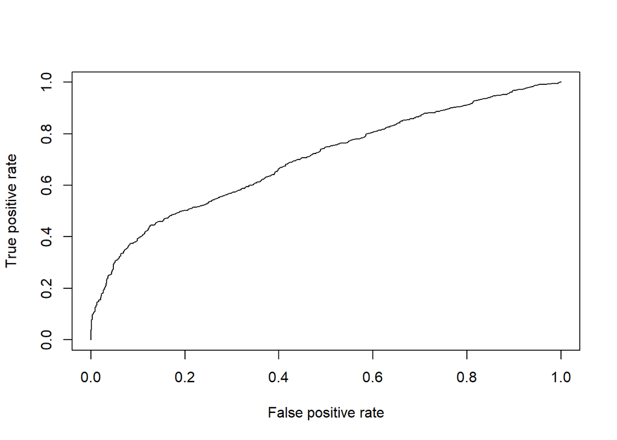

```r
gbmfit5pred = predict(gbmfit5, newdata = kobetest)
gbmfit5ROCpred=prediction(gbmfit5pred,kobetest$shot_made_flag)
gbmfit5perf=performance(gbmfit5ROCpred,"tpr","fpr")
plot(gbmfit5perf)
```

And the AUC value:

```r
as.numeric(performance(gbmfit5ROCpred,"auc")@y.values)
```

```
## [1] 0.7008511
```

#### GBM Model for Kaggle Submition

To be more accurate in Kaggle competition, we are going to use all data (`datatrain` )for predict at Kaggle.

```r
gbmfitKaggle = train(shot_made_flag~. - shot_zone_range - shot_zone_area- game_id - game_event_id - opponent - playoffs - shot_type - combined_shot_type , data = datatrain, method = "gbm", metric = "RMSE", verbose = F, trControl = ctrlforfinalmodel, tuneGrid = gbmGridFinal)
```

Final prediction is here:

```r
gbmfitKagglepred = predict(gbmfitKaggle, newdata = datatest)
```

To be in the same format that Kaggle want:

```r
submition$shot_made_flag <- gbmfitKagglepred
```

Finally, we can write submition data table as .csv and submit it in Kaggle.

### Conclusion

[output not shown]

### References

[Here](https://bradleyboehmke.github.io/HOML/gbm.html) is the source of our research about Gradient Boosting Machines.